# Final Project Code

### Source 2

For my second data source I’m scraping a web page to satisfy the requirement of having two different source types. I’m using rvest to pull the Wikipedia list of most streamed Spotify songs which gives me a real world popularity ranking that I can join back to my clustered dataset

```r
library(rvest)
url <- "https://en.wikipedia.org/wiki/List_of_most-streamed_songs_on_Spotify"

wiki_page <- read_html(url)

top_streamed <- wiki_page %>%
  html_element("table.wikitable") %>%
  html_table()

glimpse(top_streamed)
```

```
## Rows: 101
## Columns: 6
## $ Rank                <chr> "1", "2", "3", "4", "5", "6", "7", "8", "9", "10",…
## $ Song                <chr> "\"Blinding Lights\"", "\"Shape of You\"", "\"Swea…
## $ `Artist(s)`         <chr> "The Weeknd", "Ed Sheeran", "The Neighbourhood", "…
## $ `Streams(billions)` <chr> "5.406", "4.903", "4.591", "4.525", "4.402", "4.31…
## $ `Release date`      <chr> "29 November 2019", "6 January 2017", "3 December …
## $ Ref.                <chr> "[1]", "[2]", "[3]", "[4]", "[5]", "[6]", "[7]", "…
```

```r
head(top_streamed)
```

```
## # A tibble: 6 × 6
##   Rank  Song                `Artist(s)` `Streams(billions)` `Release date` Ref.
##   <chr> <chr>               <chr>       <chr>               <chr>          <chr>
## 1 1     "\"Blinding Lights… The Weeknd  5.406               29 November 2… [1]
## 2 2     "\"Shape of You\""  Ed Sheeran  4.903               6 January 2017 [2]
## 3 3     "\"Sweater Weather… The Neighb… 4.591               3 December 20… [3]
## 4 4     "\"Starboy\""       The Weeknd… 4.525               21 September … [4]
## 5 5     "\"As It Was\""     Harry Styl… 4.402               1 April 2022   [5]
## 6 6     "\"Someone You Lov… Lewis Capa… 4.315               8 November 20… [6]
```

First I need to clean up the scraped table column names since they came in with special characters and spaces which makes them hard to work with in R

```r
top_streamed <- top_streamed %>%
  rename(
    rank = Rank,
    track_name = Song,
    artists = `Artist(s)`,
    streams_billions = `Streams(billions)`,
    release_date = `Release date`
  ) %>%
  select(rank, track_name, artists, streams_billions, release_date) %>%
  mutate(
    rank = as.integer(rank),
    streams_billions = as.numeric(streams_billions),
    track_name = str_remove_all(track_name, '"')
  )
glimpse(top_streamed)
```

```
## Rows: 101
## Columns: 5
## $ rank             <int> 1, 2, 3, 4, 5, 6, 7, 8, 9, 10, 11, 12, 13, 14, 15, 16…
## $ track_name       <chr> "Blinding Lights", "Shape of You", "Sweater Weather",…
## $ artists          <chr> "The Weeknd", "Ed Sheeran", "The Neighbourhood", "The…
## $ streams_billions <dbl> 5.406, 4.903, 4.591, 4.525, 4.402, 4.315, 4.235, 4.21…
## $ release_date     <chr> "29 November 2019", "6 January 2017", "3 December 201…
```

Now I’ll join the scraped streaming data to our clustered dataset to see if any of our sampled songs appear on the most streamed list and which clusters they belong to. This connects our audio feature clustering to real world streaming success which is a meaningful insight

```r
clustered_with_streams <- audio_clustered %>%
  inner_join(top_streamed, by = "track_name")

clustered_with_streams %>%
  select(track_name, cluster_label, streams_billions) %>%
  arrange(desc(streams_billions))
```

```
## # A tibble: 16 × 3
##    track_name       cluster_label                       streams_billions
##    <chr>            <chr>                                          <dbl>
##  1 Heat Waves       Energetic & Danceable (Pop/Dance)               3.75
##  2 Señorita         Energetic & Danceable (Pop/Dance)               3.31
##  3 Señorita         Energetic & Danceable (Pop/Dance)               3.31
##  4 Watermelon Sugar Calm & Acoustic (Classical/Ambient)             3.28
##  5 Die For You      Energetic & Danceable (Pop/Dance)               3.26
##  6 Wake Me Up       Energetic & Danceable (Pop/Dance)               3.10
##  7 Shallow          Acoustic & Mellow (Folk/Indie)                  3.08
##  8 Without Me       Energetic & Danceable (Pop/Dance)               3.08
##  9 All of Me        Acoustic & Mellow (Folk/Indie)                  3.07
## 10 Beautiful Things Energetic & Danceable (Pop/Dance)               2.93
## 11 The Scientist    Calm & Acoustic (Classical/Ambient)             2.85
## 12 Take On Me       Energetic & Danceable (Pop/Dance)               2.76
## 13 Numb             High Intensity (Metal/EDM)                      2.73
## 14 Save Your Tears  Acoustic & Mellow (Folk/Indie)                  2.71
## 15 Happier          Energetic & Danceable (Pop/Dance)               2.61
## 16 Happier          Energetic & Danceable (Pop/Dance)               2.61
```

With 16 matches between our clustered songs and the world’s most streamed tracks I can now visualize which clusters the most popular songs tend to fall into. This is a meaningful real world validation of our clustering approach because if Spotify’s most streamed songs cluster together it suggests our audio feature groupings are capturing something real about what makes music resonate with listeners at scale

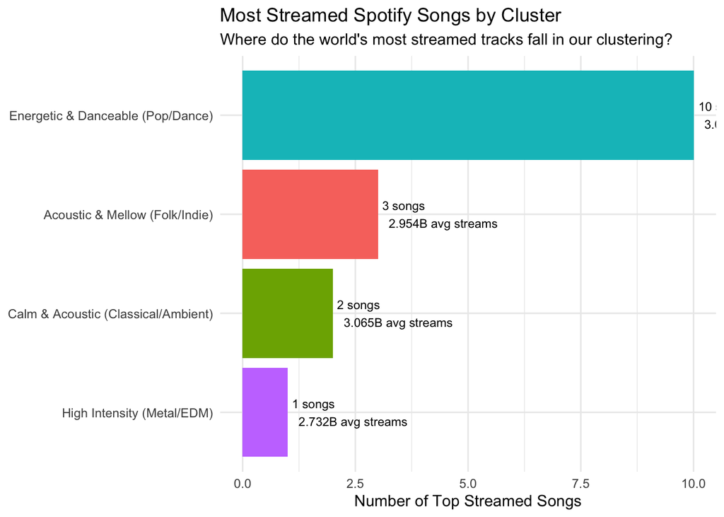

```r
clustered_with_streams %>%
  group_by(cluster_label) %>%
  summarise(
    song_count = n(),
    avg_streams = round(mean(streams_billions), 3)
  ) %>%
  arrange(desc(song_count)) %>%
  ggplot(aes(x = reorder(cluster_label, song_count),
             y = song_count, fill = cluster_label)) +
  geom_col(show.legend = FALSE) +
  geom_text(aes(label = paste0(song_count, " songs\n",
                               avg_streams, "B avg streams")),
            hjust = -0.1, size = 3) +
  coord_flip() +
  scale_y_continuous(limits = c(0, 10)) +
  labs(
    title = "Most Streamed Spotify Songs by Cluster",
    subtitle = "Where do the world's most streamed tracks fall in our clustering?",
    x = NULL,
    y = "Number of Top Streamed Songs"
  ) +
  theme_minimal()
```